# Practical Machine Learning Assignment

FPA

Sunday, May 29, 2016

```
## [1] 19622   160
```

```
## [1] A B C D E
## Levels: A B C D E
```

The label to train on is a ordinal variable, which correspond to perfect execution (=“A”) to sloppy (=“E”).

See which user_name trains in which classes.

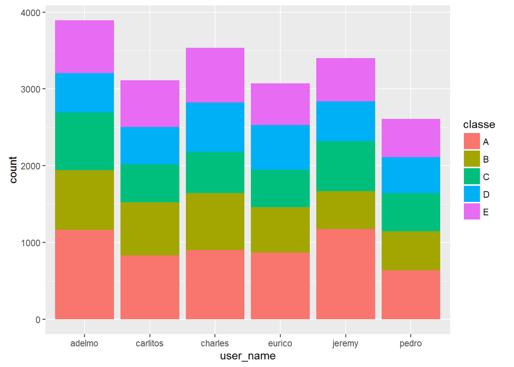

```r
library(ggplot2)
qplot(user_name, data=trainingDataPristine, geom="bar", fill=classe)
```

Ok each person trains in all classes.

Remove varibales with no information.

```r
library(caret)
nzvIndices <- nearZeroVar(trainingDataPristine)
trainingData <- trainingDataPristine[,-nzvIndices]

dim(trainingData)
```

```
## [1] 19622   100
```

100 Features left.

Now have a look if there are NAs and impute them with kNN.

```r
indexToImpute <- colSums(is.na(trainingData)) > 0

#install.packages("RANN")
preObj <- preProcess(trainingData[,-c(2,5,100)], method="knnImpute")
impTrainingData <- predict(preObj, trainingData[,-c(2,5,100)])
```

We exclude the factor variables for user_name and cvtd_timestamp from now on and decide to use only non nominal variables.

Exclude highly correlated features.

```r
corrMat <- cor(impTrainingData)
corrMat[upper.tri(corrMat)] <- 0
diag(corrMat) <- 0

highlyCorrCols <- apply(corrMat,2,function(x) any(x > 0.99))
impTrainingDataSub <- impTrainingData[,!highlyCorrCols]
dim(impTrainingData)
```

```
## [1] 19622    97
```

```r
dim(impTrainingDataSub)
```

```
## [1] 19622    92
```

Ok removed 5 variables that were highly vorrelated with other ones.

Transform the variables with PCA using the first ten principal components. This approach was chosen since most of the varibales excluding “user_name” and “cvtd_timestamp” are metrical.

```r
preProc <- preProcess(impTrainingDataSub, method="pca", pcaComp = 10)
trainPC <- predict(preProc, impTrainingDataSub)



# add label again
trainPC <- cbind(trainPC, trainingData[,100])
names(trainPC) <- c(names(trainPC)[1:length(names(trainPC))-1], "classe")
```

# Train and compare different models:

Use 10 fold cross validation:

```r
train_control<- trainControl(method="cv", number=10, savePredictions = TRUE)
```

## Stochastic Gradient Boosting

```r
gbmModel <- train(classe ~ .
                 ,trainPC
                 ,trControl=train_control
                 ,method = "gbm"
                 )
gbmModel$results
```

[output not shown]

Best model scored accuracy of 0.77.

## Linear Discriminant Analysis

```r
ldaModel <- train(classe ~ .
                 ,trainPC
                 ,trControl=train_control
                 ,method = "lda"
                 )
ldaModel$results
```

[output not shown]

Model scored accuracy of 0.50.

## Random Forest

```r
rfModel <- train(classe ~ .
                 ,trainPC
                 ,trControl=train_control
                 ,method = "rf"
                 )
rfModel$results
```

[output not shown]

Model scored accuracy of 0.95.

# Predict the test cases

Apply same preprocessing steps to the test set as they were applied to the training set

```r
#names(testingDataPristine)

testingData <- testingDataPristine[,-nzvIndices]

impTestingData <- predict(preObj, testingData[,-c(2,5,100)])

ncol(impTestingData)
```

```
## [1] 97
```

```r
testingDataSub <- impTestingData[,!highlyCorrCols]
ncol(testingDataSub)
```

```
## [1] 92
```

```r
#names(testingDataSub)
testPC <- predict(preProc, testingDataSub)
```

```r
predictions <- predict(rfModel ,testPC)
predictions
```

```
##  [1] A A A A A E D B A A B C B A E A A B B B
## Levels: A B C D E
```